# Descriptive Analysis of FEV Dataset

FE Harrell

2019-09-07

# Data Description and Univariable Statistics

```r
# results='asis' in the chunk header because html(contents) output html directly
require(Hmisc)
```

```r
knitrSet(lang='markdown', w=4, h=3)  # set default figure width and height
getHdata(FEV)
html(contents(FEV), maxlevels=10, levelType='table')
```

#### Data frame:FEV

654 observations and 6 variables, maximum # NAs:0

| Name | Units | Levels | Storage |
| --- | --- | --- | --- |
| id |  |  | integer |
| age | years |  | integer |
| fev | liters |  | double |
| height | inches |  | double |
| sex |  | 2 | integer |
| smoke |  | 2 | integer |

| Variable | Levels |
| --- | --- |
| sex | female |
|  | male |
| smoke | non-current smoker |
|  | current smoker |

```r
describe(FEV)
```

```
FEV

 6  Variables      654  Observations
---------------------------------------------------------------------------
id
       n  missing distinct     Info     Mean      Gmd      .05      .10
     654        0      654        1    37170    27213     3142     6162
     .25      .50      .75      .90      .95
   15811    36071    53638    73342    77706

lowest :   201   202   301   341   351, highest: 83841 83901 83951 83952 90001
---------------------------------------------------------------------------
age [years]
       n  missing distinct     Info     Mean      Gmd      .05      .10
     654        0       17    0.988    9.931      3.3        5        6
     .25      .50      .75      .90      .95
       8       10       12       14       15

lowest :  3  4  5  6  7, highest: 15 16 17 18 19

Value          3     4     5     6     7     8     9    10    11    12
Frequency      2     9    28    37    54    85    94    81    90    57
Proportion 0.003 0.014 0.043 0.057 0.083 0.130 0.144 0.124 0.138 0.087

Value         13    14    15    16    17    18    19
Frequency     43    25    19    13     8     6     3
Proportion 0.066 0.038 0.029 0.020 0.012 0.009 0.005
---------------------------------------------------------------------------
fev [liters]
       n  missing distinct     Info     Mean      Gmd      .05      .10
     654        0      575        1    2.637   0.9681    1.445    1.612
     .25      .50      .75      .90      .95
   1.981    2.547    3.119    3.813    4.289

lowest : 0.791 0.796 0.839 1.004 1.072, highest: 5.102 5.224 5.633 5.638 5.793
---------------------------------------------------------------------------
height [inches]
       n  missing distinct     Info     Mean      Gmd      .05      .10
     654        0       56    0.999    61.14    6.497     51.0     53.0
     .25      .50      .75      .90      .95
    57.0     61.5     65.5     68.5     70.0

lowest : 46.0 46.5 47.0 48.0 49.0, highest: 72.0 72.5 73.0 73.5 74.0
---------------------------------------------------------------------------
sex
       n  missing distinct
     654        0        2

Value      female   male
Frequency     318    336
Proportion  0.486  0.514
---------------------------------------------------------------------------
smoke
       n  missing distinct
     654        0        2

Value      non-current smoker     current smoker
Frequency                 589                 65
Proportion              0.901              0.099
---------------------------------------------------------------------------
```

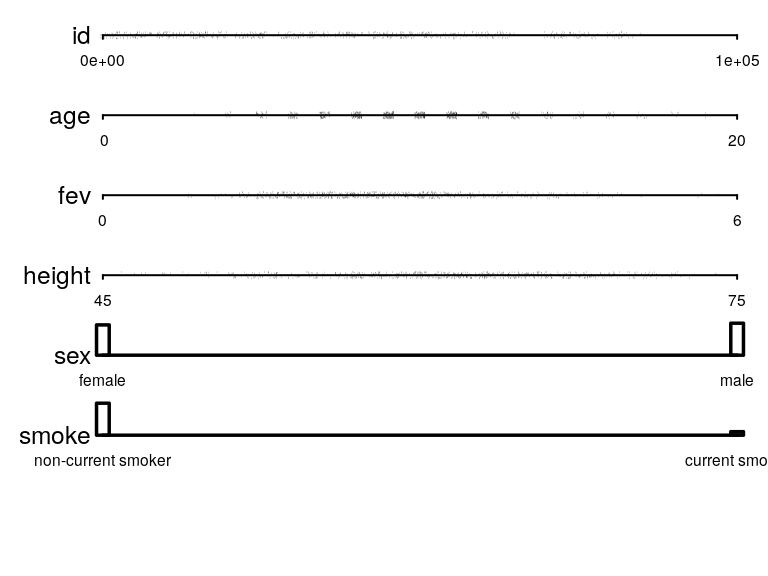

```r
datadensity(FEV)
```

# Comparison of Distributions for Smokers and Non-Smokers

Some of the output below uses extended box plots. A schematic for interpreting them is below. Go [here](http://biostat.mc.vanderbilt.edu/HmiscNew) for more examples of `Hmisc` graphical summarization functions.

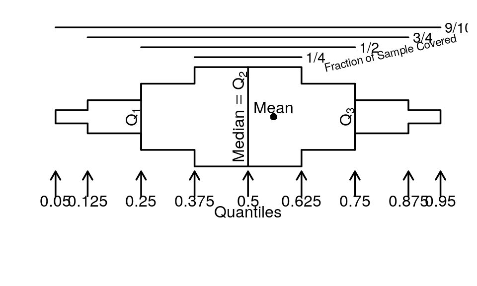

```r
bpplt()
```

The table below includes quartiles for continuous variables.

```r
s <- summaryM(age + fev + height + sex ~ smoke, data=FEV)
print(s, npct='both', round=2)
```

```
Descriptive Statistics  (N=654)

+----------+-------------------+---------------+
|          |non-current smoker |current smoker |
|          |(N=589)            |(N=65)         |
+----------+-------------------+---------------+
|age       |    8/ 9/11        |   12/13/15    |
+----------+-------------------+---------------+
|fev       |1.92/2.46/3.05     |2.80/3.17/3.75 |
+----------+-------------------+---------------+
|height    |57.0/61.0/64.5     |63.5/66.0/68.0 |
+----------+-------------------+---------------+
|sex : male| 0.53 310/589      | 0.40  26/ 65  |
+----------+-------------------+---------------+
```

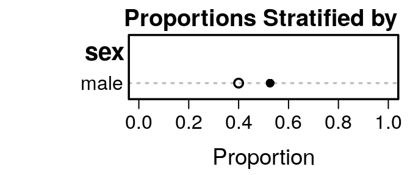

```r
plot(s, which='categorical')
```

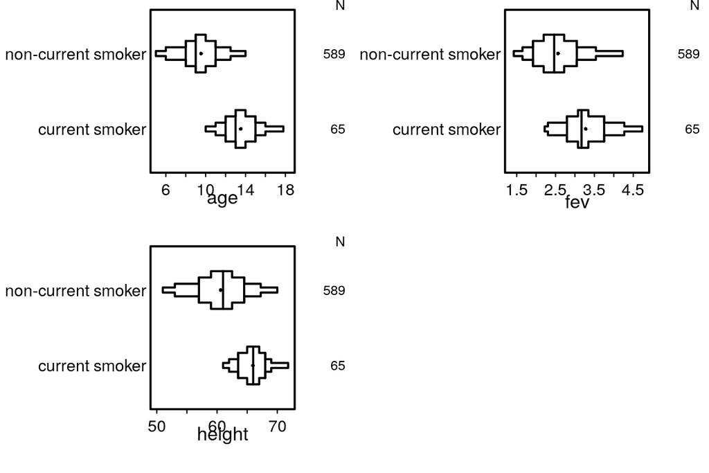

```r
plot(s, which='continuous')
```

Another way to describe categorical variables:

```r
s <- summaryP(sex ~ smoke, data=FEV)
s
```

```
  var    val freq denom              smoke
1 sex female  279   589 non-current smoker
2 sex   male  310   589 non-current smoker
3 sex female   39    65     current smoker
4 sex   male   26    65     current smoker
```

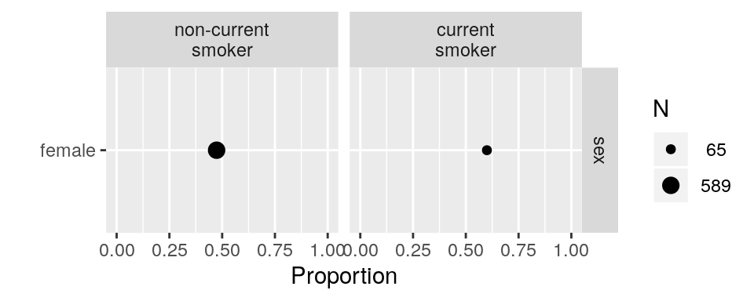

```r
ggplot(s)
```

Another way to describe continuous variables:

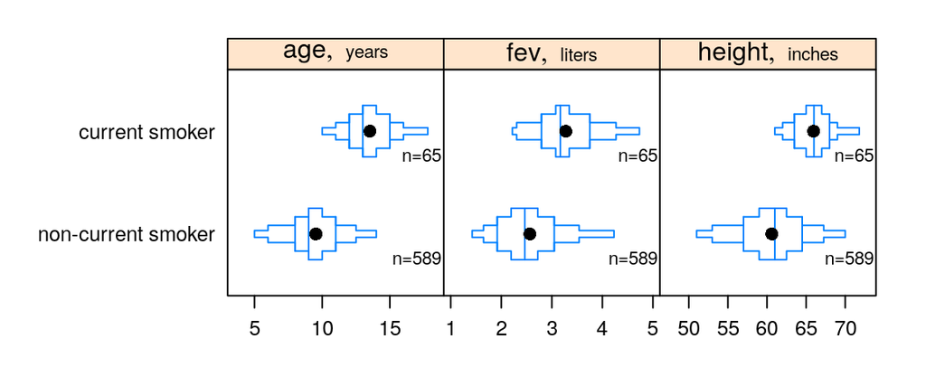

```r
bpplotM(age + fev + height ~ smoke, data=FEV)
```

# Relationship between FEV1 and other variables

The following shows mean FEV1 and stratifies by smoking status and, in an extraordinarily information-losing fashion, by quartiles of continuous subject characteristics using the `Hmisc` package `summary.formula` function.

```r
s <- summary(fev ~ age + height + sex + smoke, data=FEV)
s
```

```
fev     N= 654

+---------------+------------------+---+--------+
|               |                  |N  |fev     |
+---------------+------------------+---+--------+
|age [years]    |[ 3, 9)           |215|1.858228|
|               |[ 9,11)           |175|2.551571|
|               |[11,13)           |147|3.110728|
|               |[13,19]           |117|3.599427|
+---------------+------------------+---+--------+
|height [inches]|[46.0,57.5)       |165|1.703945|
|               |[57.5,62.0)       |174|2.370339|
|               |[62.0,66.0)       |167|2.870964|
|               |[66.0,74.0]       |148|3.725764|
+---------------+------------------+---+--------+
|sex            |female            |318|2.451170|
|               |male              |336|2.812446|
+---------------+------------------+---+--------+
|smoke          |non-current smoker|589|2.566143|
|               |current smoker    | 65|3.276862|
+---------------+------------------+---+--------+
|Overall        |                  |654|2.636780|
+---------------+------------------+---+--------+
```

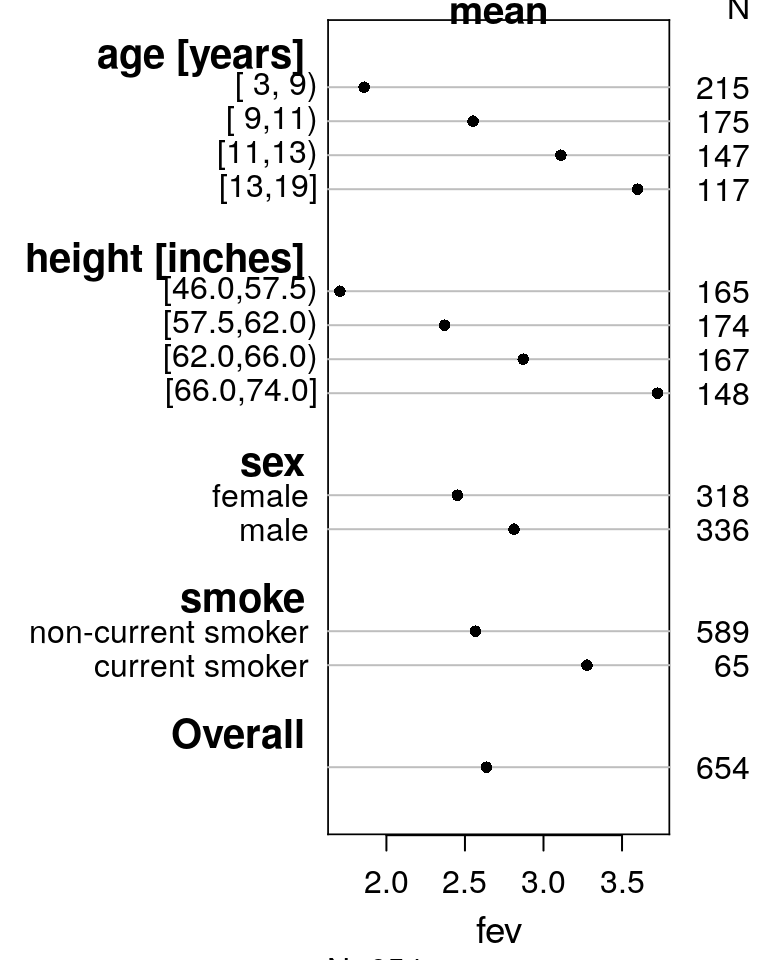

```r
plot(s)
```

Much more effective is to use the *loess* smoother to show the relationship between continuous variables and FEV1. Marginal distributions of age and height are shown using extended box plots at the top of the plots. Feint tick marks show the data density of age and height for each smoking group.

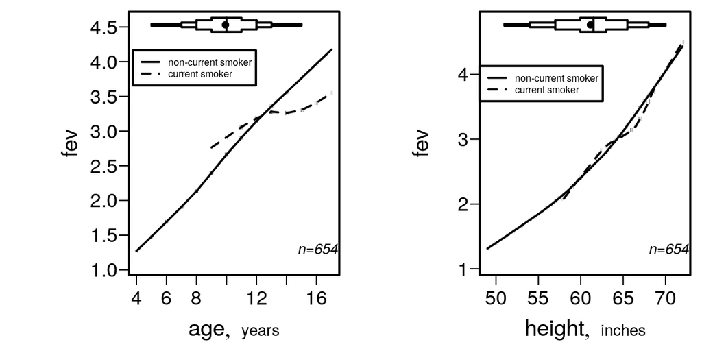

```r
par(mfrow=c(1,2))   # one row, two column graphic
summaryRc(fev ~ age + height + stratify(smoke), data=FEV,
          label.curves=list(keys='lines', cex=.5), bpplot='top', nloc=list(x=.9, y=.1))
```

R Core Team (2019). *R: A Language and Environment for Statistical Computing*. R Foundation for Statistical Computing, Vienna, Austria. <URL: https://www.R-project.org/>.